# Submit2

Runan Yao

October 2, 2018

# Goal

1. Do pathway analysis based on target cell lines (treatable cell lines) and other cell lines (untreatable cell lines).
2. Try find a model to classify the treatable cell lines vs. untreatable cell lines.

# 0. Read data

```r
allDegResult <- read.csv("Phase_1_Result/FC FDR of each cell line/AllDEGResult.csv", stringsAsFactors = FALSE)
colnames(allDegResult)
```

```
##  [1] "X"
##  [2] "Gene"
##  [3] "Symbol_184A1"
##  [4] "X184A1TR.X184A1NT___log2FoldChange"
##  [5] "X184A1TR.X184A1NT___padj"
##  [6] "XC32TR.XC32NT___log2FoldChange"
##  [7] "XC32TR.XC32NT___padj"
##  [8] "XCCD18TR.XCCD18NT___log2FoldChange"
##  [9] "XCCD18TR.XCCD18NT___padj"
## [10] "XHEMTR.XHEMNT___log2FoldChange"
## [11] "XHEMTR.XHEMNT___padj"
## [12] "XHT29TR.XHT29NT___log2FoldChange"
## [13] "XHT29TR.XHT29NT___padj"
## [14] "XhTERTTR.XhTERTNT___log2FoldChange"
## [15] "XhTERTTR.XhTERTNT___padj"
## [16] "XMCF7TR.XMCF7NT___log2FoldChange"
## [17] "XMCF7TR.XMCF7NT___padj"
## [18] "XPANCTR.XPANCNT___log2FoldChange"
## [19] "XPANCTR.XPANCNT___padj"
## [20] "XPC3TR.XPC3NT___log2FoldChange"
## [21] "XPC3TR.XPC3NT___padj"
## [22] "XPC3MTR.XPC3MNT___log2FoldChange"
## [23] "XPC3MTR.XPC3MNT___padj"
## [24] "XRWTR.XRWNT___log2FoldChange"
## [25] "XRWTR.XRWNT___padj"
## [26] "XTRAMPTR.XTRAMPNT___log2FoldChange"
## [27] "XTRAMPTR.XTRAMPNT___padj"
```

# 1. Preprocess

## 1.1 Regroup

```r
allNames <- colnames(allDegResult)
expGroupNames <- c( 'XPC3TR.XPC3NT___log2FoldChange',
                    'XPC3TR.XPC3NT___padj',
                    'XPC3MTR.XPC3MNT___log2FoldChange',
                    'XPC3MTR.XPC3MNT___padj',
                    'XMCF7TR.XMCF7NT___log2FoldChange',
                    'XMCF7TR.XMCF7NT___padj')
ExpGroup <- allDegResult %>%
  select(one_of( c( 'Gene',expGroupNames)))

colnames(ExpGroup) <- c('Gene',
                        'Exp_LFC_1', 'Exp_Alpha_1',
                        'Exp_LFC_2', 'Exp_Alpha_2',
                        'Exp_LFC_3', 'Exp_Alpha_3')
sampleNames.Exp <- c('PC3','PC3M','MCF7')

CtrlGroup <- allDegResult %>%
  select(one_of(setdiff( allNames, c(expGroupNames, c('X', 'Symbol_184A1', 'XTRAMPTR.XTRAMPNT___log2FoldChange', 'XTRAMPTR.XTRAMPNT___padj')))))

colnames(CtrlGroup) <- c('Gene',
                         'CTRL_LFC_1', 'CTRL_Alpha_1',
                         'CTRL_LFC_2', 'CTRL_Alpha_2',
                         'CTRL_LFC_3', 'CTRL_Alpha_3',
                         'CTRL_LFC_4', 'CTRL_Alpha_4',
                         'CTRL_LFC_5', 'CTRL_Alpha_5',
                         'CTRL_LFC_6', 'CTRL_Alpha_6',
                         'CTRL_LFC_7', 'CTRL_Alpha_7',
                         'CTRL_LFC_8', 'CTRL_Alpha_8')
sampleNames.Ctrl <- c('184A1', 'C32', 'CCD18', 'HEM', 'HT29', 'hTERT', 'PANC', 'RW')
```

## 1.2 In each cell-line, for each gene, if adj-alpha value is < threshold, then keep LFC otherwise set LFC = 0

```r
ourThreshold <- 0.5
keepOrNot <- function(alpha, threshold){
  return(
    ifelse(is.na(alpha),
           0,
           ifelse(alpha < threshold,
                  1,
                  0)
           )
    )
}

Exp1 <- ExpGroup$Exp_LFC_1 * keepOrNot(ExpGroup$Exp_Alpha_1, threshold = ourThreshold)
Exp2 <- ExpGroup$Exp_LFC_2 * keepOrNot(ExpGroup$Exp_Alpha_2, threshold = ourThreshold)
Exp3 <- ExpGroup$Exp_LFC_3 * keepOrNot(ExpGroup$Exp_Alpha_3, threshold = ourThreshold)

Ctrl1 <- CtrlGroup$CTRL_LFC_1 * keepOrNot(CtrlGroup$CTRL_Alpha_1, threshold = ourThreshold)
Ctrl2 <- CtrlGroup$CTRL_LFC_2 * keepOrNot(CtrlGroup$CTRL_Alpha_2, threshold = ourThreshold)
Ctrl3 <- CtrlGroup$CTRL_LFC_3 * keepOrNot(CtrlGroup$CTRL_Alpha_3, threshold = ourThreshold)
Ctrl4 <- CtrlGroup$CTRL_LFC_4 * keepOrNot(CtrlGroup$CTRL_Alpha_4, threshold = ourThreshold)
Ctrl5 <- CtrlGroup$CTRL_LFC_5 * keepOrNot(CtrlGroup$CTRL_Alpha_5, threshold = ourThreshold)
Ctrl6 <- CtrlGroup$CTRL_LFC_6 * keepOrNot(CtrlGroup$CTRL_Alpha_6, threshold = ourThreshold)
Ctrl7 <- CtrlGroup$CTRL_LFC_7 * keepOrNot(CtrlGroup$CTRL_Alpha_7, threshold = ourThreshold)
Ctrl8 <- CtrlGroup$CTRL_LFC_8 * keepOrNot(CtrlGroup$CTRL_Alpha_8, threshold = ourThreshold)

length(Exp1)
```

```
## [1] 39384
```

```r
LFCTable <- cbind(Exp1,Exp2,Exp3,Ctrl1,Ctrl2,Ctrl3,Ctrl4,Ctrl5,Ctrl6,Ctrl7,Ctrl8)

dim(LFCTable)
```

```
## [1] 39384    11
```

```r
colnames(LFCTable) <- c('Exp_1','Exp_2','Exp_3','Ctrl_1','Ctrl_2','Ctrl_3','Ctrl_4','Ctrl_5','Ctrl_6','Ctrl_7','Ctrl_8')
rownames(LFCTable) <- ExpGroup$Gene

LFCTable[is.na(LFCTable)] <- 0

#
# upRegLFCTable <- ifelse(LFCTable > 0, LFCTable, 0 )
# ConvertedUpRegLFCTable <- floor(2^upRegLFCTable * 1000)
#

NormalizeLFCNumber <- function(x){
  return(x-min(x))
}

normalizedLFCTable <- apply(LFCTable,2, NormalizeLFCNumber)
summary(normalizedLFCTable)
```

```
##      Exp_1            Exp_2            Exp_3            Ctrl_1
##  Min.   : 0.000   Min.   : 0.000   Min.   : 0.000   Min.   : 0.000
##  1st Qu.: 9.195   1st Qu.: 8.988   1st Qu.: 7.533   1st Qu.: 6.945
##  Median : 9.195   Median : 8.988   Median : 7.533   Median : 6.945
##  Mean   : 9.205   Mean   : 8.992   Mean   : 7.571   Mean   : 6.994
##  3rd Qu.: 9.195   3rd Qu.: 8.988   3rd Qu.: 7.533   3rd Qu.: 6.945
##  Max.   :19.138   Max.   :18.622   Max.   :17.687   Max.   :19.178
##      Ctrl_2           Ctrl_3           Ctrl_4           Ctrl_5
##  Min.   : 0.000   Min.   : 0.000   Min.   : 0.000   Min.   : 0.000
##  1st Qu.: 6.163   1st Qu.: 7.149   1st Qu.: 4.092   1st Qu.: 7.292
##  Median : 6.163   Median : 7.149   Median : 4.092   Median : 7.292
##  Mean   : 6.181   Mean   : 7.149   Mean   : 4.105   Mean   : 7.274
##  3rd Qu.: 6.163   3rd Qu.: 7.149   3rd Qu.: 4.092   3rd Qu.: 7.292
##  Max.   :16.104   Max.   :14.873   Max.   :13.979   Max.   :14.723
##      Ctrl_6          Ctrl_7           Ctrl_8
##  Min.   : 0.00   Min.   : 0.000   Min.   : 0.000
##  1st Qu.:10.14   1st Qu.: 8.972   1st Qu.: 8.931
##  Median :10.14   Median : 8.972   Median : 8.931
##  Mean   :10.15   Mean   : 8.990   Mean   : 8.934
##  3rd Qu.:10.14   3rd Qu.: 8.972   3rd Qu.: 8.931
##  Max.   :21.02   Max.   :17.179   Max.   :17.920
```

```r
convertedLFCTable <- normalizedLFCTable
summary(convertedLFCTable)
```

```
##      Exp_1            Exp_2            Exp_3            Ctrl_1
##  Min.   : 0.000   Min.   : 0.000   Min.   : 0.000   Min.   : 0.000
##  1st Qu.: 9.195   1st Qu.: 8.988   1st Qu.: 7.533   1st Qu.: 6.945
##  Median : 9.195   Median : 8.988   Median : 7.533   Median : 6.945
##  Mean   : 9.205   Mean   : 8.992   Mean   : 7.571   Mean   : 6.994
##  3rd Qu.: 9.195   3rd Qu.: 8.988   3rd Qu.: 7.533   3rd Qu.: 6.945
##  Max.   :19.138   Max.   :18.622   Max.   :17.687   Max.   :19.178
##      Ctrl_2           Ctrl_3           Ctrl_4           Ctrl_5
##  Min.   : 0.000   Min.   : 0.000   Min.   : 0.000   Min.   : 0.000
##  1st Qu.: 6.163   1st Qu.: 7.149   1st Qu.: 4.092   1st Qu.: 7.292
##  Median : 6.163   Median : 7.149   Median : 4.092   Median : 7.292
##  Mean   : 6.181   Mean   : 7.149   Mean   : 4.105   Mean   : 7.274
##  3rd Qu.: 6.163   3rd Qu.: 7.149   3rd Qu.: 4.092   3rd Qu.: 7.292
##  Max.   :16.104   Max.   :14.873   Max.   :13.979   Max.   :14.723
##      Ctrl_6          Ctrl_7           Ctrl_8
##  Min.   : 0.00   Min.   : 0.000   Min.   : 0.000
##  1st Qu.:10.14   1st Qu.: 8.972   1st Qu.: 8.931
##  Median :10.14   Median : 8.972   Median : 8.931
##  Mean   :10.15   Mean   : 8.990   Mean   : 8.934
##  3rd Qu.:10.14   3rd Qu.: 8.972   3rd Qu.: 8.931
##  Max.   :21.02   Max.   :17.179   Max.   :17.920
```

```r
write.csv(LFCTable, file='Phase_2_Result/Filtered_LFC_Result.csv', row.names = TRUE)
write.csv(convertedLFCTable, file='Phase_2_Result/convertedLFC_Result.csv', row.names = TRUE)
LFCTable <- as.data.frame(LFCTable, stringsAsFactors = FALSE)
```

### all zero LFC

```r
dim(LFCTable)
```

```
## [1] 39384    11
```

```r
result <- apply(LFCTable,1, function(x){all(x==0)})

sum(result)
```

```
## [1] 18903
```

# 2. Test

## 2.1 Some basic calculation

For each gene, assume the gene LFC can only be picked from one of two distributions.

Then the chance of having Exp_1~Exp_3 from one group and Ctrl_1~Ctrl_8 from the other group is $\frac{2}{2^{11}}$.

Note 1: Only two distributions exist is already a very strong requirement. The more distributions we have, the lower above chance is.

Note 2: The mean of this two distribution may have same sign, which means the LFC can both positive or negative in these two groups.

## 2.2 Different direction of express in between groups

The ideal case is:

1. Exp group all up, Ctrl group all down; or
2. Exp group all down, Ctrl group all up

```r
sameInExpUpCtrlDownOrKeep <- apply(LFCTable,1, function(x){ all(x[1:3] > 0) && all(x[4:11] <= 0) } )
sameInExpUpOrKeepCtrlDown <- apply(LFCTable,1, function(x){ all(x[1:3] >= 0) && all(x[4:11] < 0) } )
sameInExpDownCtrlUpOrKeep <- apply(LFCTable,1, function(x){ all(x[1:3] < 0) && all(x[4:11] >= 0) } )
sameInExpDownOrKeepCtrlUp <- apply(LFCTable,1, function(x){ all(x[1:3] <= 0) && all(x[4:11] > 0) } )

names(sameInExpUpOrKeepCtrlDown) = NULL
names(sameInExpUpCtrlDownOrKeep) = NULL
names(sameInExpDownCtrlUpOrKeep) = NULL
names(sameInExpDownOrKeepCtrlUp) = NULL

which(sameInExpUpOrKeepCtrlDown == TRUE)
```

```
## integer(0)
```

```r
which(sameInExpUpCtrlDownOrKeep == TRUE)
```

```
## [1] 23081
```

```r
which(sameInExpDownCtrlUpOrKeep == TRUE)
```

```
##  [1]  1807  2034  4629  5597  6458  6847  6938 10173 11426 18473 21647
## [12] 23011
```

```r
which(sameInExpDownOrKeepCtrlUp == TRUE)
```

```
## integer(0)
```

Here we can see, none of those genes follow the ideal case.

## 2.3 T.test

```r
matrixLFC <- as.matrix(LFCTable)
colnames(matrixLFC) <- NULL
rownames(matrixLFC) <- NULL
runTTest <- function(x){
  return(t.test(x[1:3], x[4:11] )$p.value)
}
tTestResult <- apply(matrixLFC, 1, runTTest)
sum(tTestResult<0.05, na.rm = TRUE)
```

```
## [1] 500
```

```r
length(tTestResult)
```

```
## [1] 39384
```

```r
ExpGroup$Gene[which(tTestResult<0.05)]
```

```
##   [1] "ENSG00000001460" "ENSG00000005469" "ENSG00000006459"
##   [4] "ENSG00000006468" "ENSG00000010256" "ENSG00000013588"
##   [7] "ENSG00000018610" "ENSG00000020426" "ENSG00000023041"
##  [10] "ENSG00000023608" "ENSG00000023697" "ENSG00000025293"
##  [13] "ENSG00000029534" "ENSG00000047056" "ENSG00000055163"
##  [16] "ENSG00000057704" "ENSG00000059691" "ENSG00000063245"
##  [19] "ENSG00000063587" "ENSG00000064199" "ENSG00000065057"
##  [22] "ENSG00000065243" "ENSG00000065491" "ENSG00000068394"
##  [25] "ENSG00000069702" "ENSG00000070444" "ENSG00000070770"
##  [28] "ENSG00000072778" "ENSG00000073060" "ENSG00000074319"
##  [31] "ENSG00000075239" "ENSG00000075240" "ENSG00000075651"
##  [34] "ENSG00000076053" "ENSG00000076662" "ENSG00000078246"
##  [37] "ENSG00000079435" "ENSG00000083720" "ENSG00000083828"
##  [40] "ENSG00000083844" "ENSG00000084093" "ENSG00000084112"
##  [43] "ENSG00000084636" "ENSG00000084731" "ENSG00000087157"
```

[output cut: 152 more lines]

# 3. Pathway analysis

## 3.1 Using Gage do pathway analysis

```r
library(gage)
library(gageData)
library("org.Hs.eg.db")
```

```r
#dim(LFCTable)
dfLFCTable <- as.numeric( rowMeans(LFCTable[,1:3]) - rowMeans(LFCTable[,4:11]) )
#dim(dfLFCTable)
names(dfLFCTable) = mapIds(org.Hs.eg.db,
                     keys=row.names(LFCTable),
                     column="ENTREZID",
                     keytype="ENSEMBL",
                     multiVals="first")
data(kegg.sets.hs)
data(sigmet.idx.hs)
kegg.sets.hs = kegg.sets.hs[sigmet.idx.hs]

kres = gage(dfLFCTable, gsets=kegg.sets.hs, same.dir=TRUE)
lapply(kres, head)
```

```
## $greater
##                                                     p.geomean stat.mean
## hsa03030 DNA replication                         7.167496e-07  5.300794
## hsa04110 Cell cycle                              1.559649e-06  4.781979
## hsa03410 Base excision repair                    8.395507e-04  3.282929
## hsa04114 Oocyte meiosis                          1.157722e-03  3.085205
## hsa03440 Homologous recombination                1.189069e-03  3.189267
## hsa04914 Progesterone-mediated oocyte maturation 2.199077e-03  2.889272
##                                                         p.val        q.val
## hsa03030 DNA replication                         7.167496e-07 0.0001168302
## hsa04110 Cell cycle                              1.559649e-06 0.0001271114
## hsa03410 Base excision repair                    8.395507e-04 0.0387636611
## hsa04114 Oocyte meiosis                          1.157722e-03 0.0387636611
## hsa03440 Homologous recombination                1.189069e-03 0.0387636611
## hsa04914 Progesterone-mediated oocyte maturation 2.199077e-03 0.0559293129
##                                                  set.size         exp1
## hsa03030 DNA replication                               36 7.167496e-07
## hsa04110 Cell cycle                                   122 1.559649e-06
## hsa03410 Base excision repair                          33 8.395507e-04
## hsa04114 Oocyte meiosis                               104 1.157722e-03
## hsa03440 Homologous recombination                      28 1.189069e-03
## hsa04914 Progesterone-mediated oocyte maturation       82 2.199077e-03
##
## $less
##                                                         p.geomean
## hsa04141 Protein processing in endoplasmic reticulum 0.0003764521
## hsa03060 Protein export                              0.0049743836
## hsa04330 Notch signaling pathway                     0.0390154557
## hsa00590 Arachidonic acid metabolism                 0.0736439608
## hsa04370 VEGF signaling pathway                      0.0782605817
## hsa03008 Ribosome biogenesis in eukaryotes           0.1152535434
##                                                      stat.mean
## hsa04141 Protein processing in endoplasmic reticulum -3.402569
## hsa03060 Protein export                              -2.715257
## hsa04330 Notch signaling pathway                     -1.784777
## hsa00590 Arachidonic acid metabolism                 -1.464178
## hsa04370 VEGF signaling pathway                      -1.425675
## hsa03008 Ribosome biogenesis in eukaryotes           -1.205378
##                                                             p.val
## hsa04141 Protein processing in endoplasmic reticulum 0.0003764521
```

[output cut: 13 more lines]

```
## hsa04141 Protein processing in endoplasmic reticulum 0.0003764521
## hsa03060 Protein export                              0.0049743836
## hsa04330 Notch signaling pathway                     0.0390154557
## hsa00590 Arachidonic acid metabolism                 0.0736439608
## hsa04370 VEGF signaling pathway                      0.0782605817
## hsa03008 Ribosome biogenesis in eukaryotes           0.1152535434
##
## $stats
##                                                  stat.mean     exp1
## hsa03030 DNA replication                          5.300794 5.300794
## hsa04110 Cell cycle                               4.781979 4.781979
## hsa03410 Base excision repair                     3.282929 3.282929
## hsa04114 Oocyte meiosis                           3.085205 3.085205
## hsa03440 Homologous recombination                 3.189267 3.189267
## hsa04914 Progesterone-mediated oocyte maturation  2.889272 2.889272
```

```r
k_pathways_Up = data.frame(id=rownames(kres$greater), kres$greater) %>%
  tbl_df() %>%
  filter(row_number()<=5) %>%
  .$id %>%
  as.character()

k_pathways_Down = data.frame(id=rownames(kres$less), kres$less) %>%
  tbl_df() %>%
  filter(row_number()<=5) %>%
  .$id %>%
  as.character()

k_Up_ids = unique(substr(k_pathways_Up, start=1, stop=8))
k_Down_ids = unique(substr(k_pathways_Down, start=1, stop=8))
k_Up_ids
```

```
## [1] "hsa03030" "hsa04110" "hsa03410" "hsa04114" "hsa03440"
```

```r
k_Down_ids
```

```
## [1] "hsa04141" "hsa03060" "hsa04330" "hsa00590" "hsa04370"
```

## 3.2 Do pathway view

```r
library(pathview)
```

### Up regulated pathways

The following pathways up regulated more or down regulated less in PC3, PC3M, MCF7 than in the other cell lines.

```r
pathview(gene.data=dfLFCTable, pathway.id=upid, species="hsa", kegg.dir = "PathviewResult/Up/", new.signature=FALSE)
```

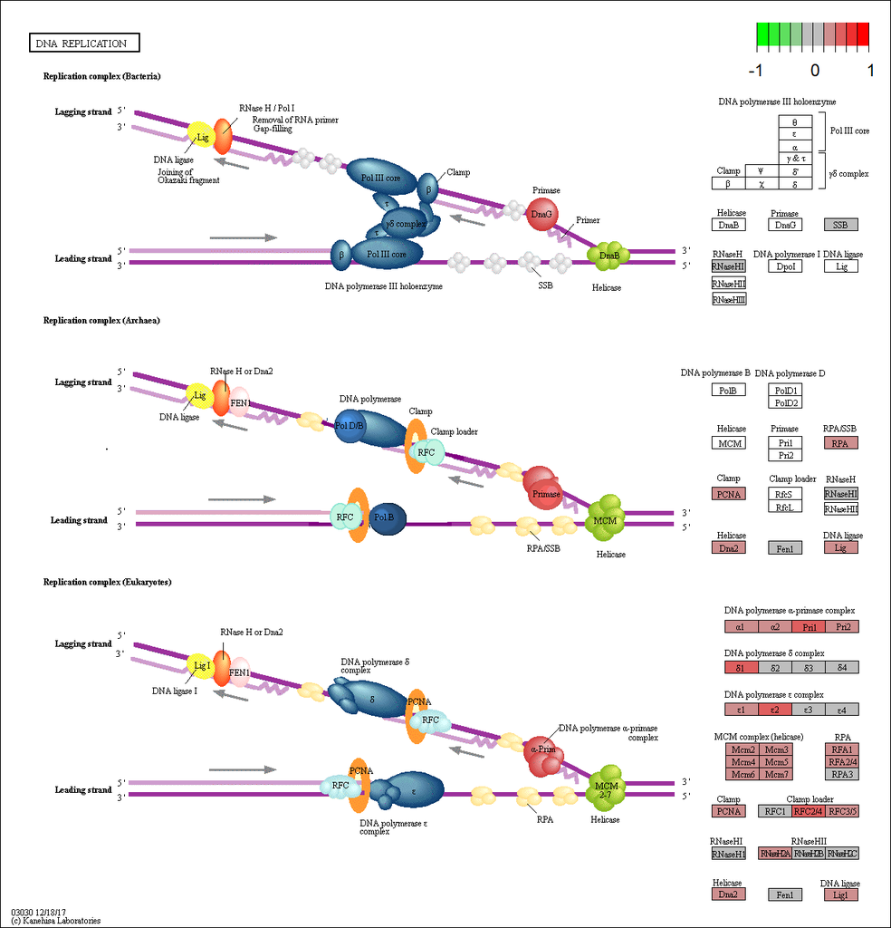

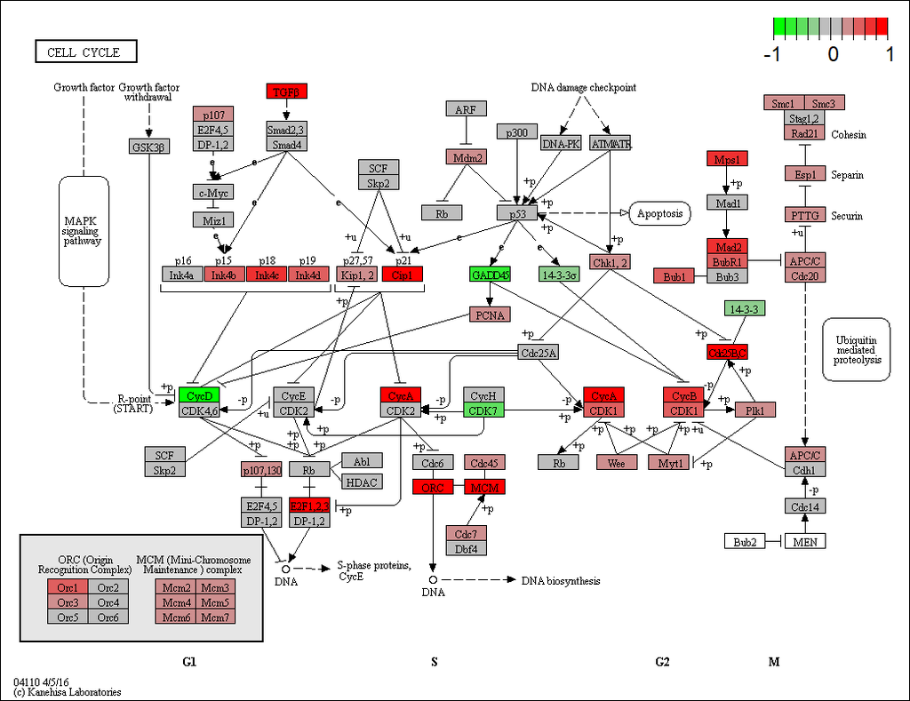

[figure not shown]

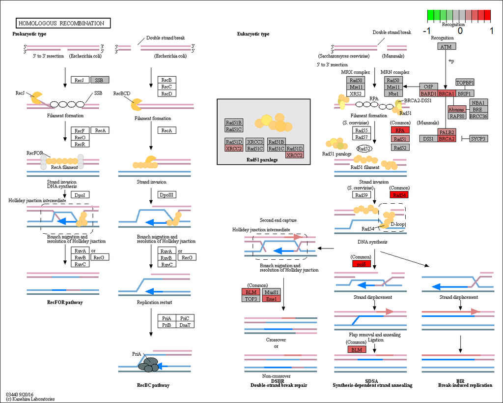

[figure not shown]

### Down regulated pathways

The following pathways up regulated less or down regulated more in PC3, PC3M, MCF7 than in the other cell lines.

```r
pathview(gene.data=dfLFCTable, pathway.id=k_Down_ids, species="hsa", kegg.dir = "PathviewResult/Down/", new.signature=FALSE)
```

[figure not shown]

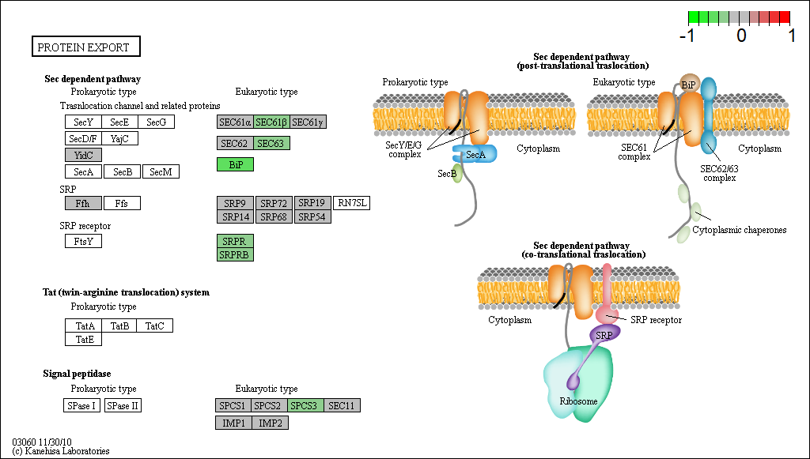

[figure not shown]

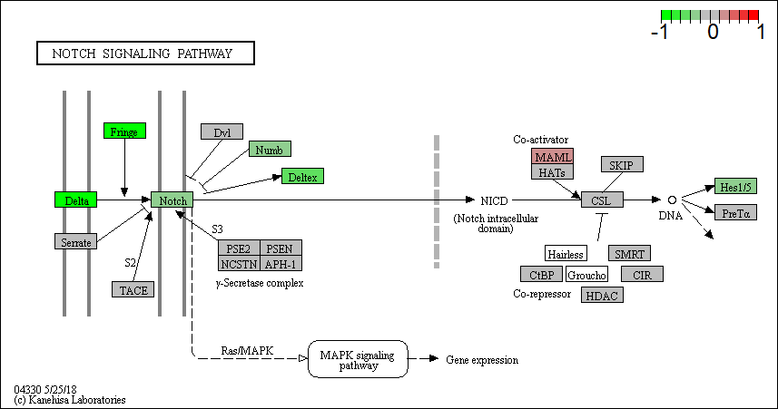

[figure not shown]

## 3.3 Gage Analysis using GO

```r
data(go.sets.hs)
data(go.subs.hs)
GoLFC = dfLFCTable

gobpsets = go.sets.hs[go.subs.hs$BP]
goccsets = go.sets.hs[go.subs.hs$CC]
gomfsets = go.sets.hs[go.subs.hs$MF]

gobpres <- gage(GoLFC, gsets=gobpsets, same.dir=TRUE)
goccres <- gage(GoLFC, gsets=goccsets, same.dir=TRUE)
gomfres <- gage(GoLFC, gsets=gomfsets, same.dir=TRUE)
```

### bp result

```r
lapply(gobpres, head)
```

```
## $greater
##                                             p.geomean stat.mean
## GO:0000279 M phase                       2.249498e-16  8.288368
## GO:0000087 M phase of mitotic cell cycle 4.048448e-14  7.651588
## GO:0048285 organelle fission             6.789269e-14  7.569155
## GO:0000280 nuclear division              6.901625e-14  7.581094
## GO:0007067 mitosis                       6.901625e-14  7.581094
## GO:0007017 microtubule-based process     2.910978e-13  7.322616
##                                                 p.val        q.val
## GO:0000279 M phase                       2.249498e-16 9.234191e-13
## GO:0000087 M phase of mitotic cell cycle 4.048448e-14 5.666234e-11
## GO:0048285 organelle fission             6.789269e-14 5.666234e-11
## GO:0000280 nuclear division              6.901625e-14 5.666234e-11
## GO:0007067 mitosis                       6.901625e-14 5.666234e-11
## GO:0007017 microtubule-based process     2.910978e-13 1.991594e-10
##                                          set.size         exp1
## GO:0000279 M phase                            497 2.249498e-16
## GO:0000087 M phase of mitotic cell cycle      361 4.048448e-14
## GO:0048285 organelle fission                  375 6.789269e-14
## GO:0000280 nuclear division                   351 6.901625e-14
## GO:0007067 mitosis                            351 6.901625e-14
## GO:0007017 microtubule-based process          419 2.910978e-13
##
## $less
##                                                          p.geomean
## GO:0006986 response to unfolded protein                0.001422317
## GO:0035966 response to topologically incorrect protein 0.001623299
## GO:0030433 ER-associated protein catabolic process     0.003392014
## GO:0006984 ER-nucleus signaling pathway                0.003484725
## GO:0042254 ribosome biogenesis                         0.003532464
## GO:0022613 ribonucleoprotein complex biogenesis        0.003816460
##                                                        stat.mean
## GO:0006986 response to unfolded protein                -3.017898
## GO:0035966 response to topologically incorrect protein -2.973830
## GO:0030433 ER-associated protein catabolic process     -2.790093
## GO:0006984 ER-nucleus signaling pathway                -2.733261
## GO:0042254 ribosome biogenesis                         -2.714946
## GO:0022613 ribonucleoprotein complex biogenesis        -2.681347
##                                                              p.val q.val
## GO:0006986 response to unfolded protein                0.001422317     1
```

[output cut: 13 more lines]

```
## GO:0006986 response to unfolded protein                0.001422317
## GO:0035966 response to topologically incorrect protein 0.001623299
## GO:0030433 ER-associated protein catabolic process     0.003392014
## GO:0006984 ER-nucleus signaling pathway                0.003484725
## GO:0042254 ribosome biogenesis                         0.003532464
## GO:0022613 ribonucleoprotein complex biogenesis        0.003816460
##
## $stats
##                                          stat.mean     exp1
## GO:0000279 M phase                        8.288368 8.288368
## GO:0000087 M phase of mitotic cell cycle  7.651588 7.651588
## GO:0048285 organelle fission              7.569155 7.569155
## GO:0000280 nuclear division               7.581094 7.581094
## GO:0007067 mitosis                        7.581094 7.581094
## GO:0007017 microtubule-based process      7.322616 7.322616
```

### cc result

```r
lapply(goccres, head)
```

```
## $greater
##                                                        p.geomean stat.mean
## GO:0000793 condensed chromosome                     3.606901e-13  7.499553
## GO:0000775 chromosome, centromeric region           6.561662e-13  7.440533
## GO:0044427 chromosomal part                         4.569394e-12  6.906000
## GO:0005819 spindle                                  6.548566e-11  6.583964
## GO:0000779 condensed chromosome, centromeric region 9.519825e-11  6.823599
## GO:0000776 kinetochore                              2.189033e-10  6.583394
##                                                            p.val
## GO:0000793 condensed chromosome                     3.606901e-13
## GO:0000775 chromosome, centromeric region           6.561662e-13
## GO:0044427 chromosomal part                         4.569394e-12
## GO:0005819 spindle                                  6.548566e-11
## GO:0000779 condensed chromosome, centromeric region 9.519825e-11
## GO:0000776 kinetochore                              2.189033e-10
##                                                            q.val set.size
## GO:0000793 condensed chromosome                     1.604326e-10      162
## GO:0000775 chromosome, centromeric region           1.604326e-10      146
## GO:0044427 chromosomal part                         7.448112e-10      500
## GO:0005819 spindle                                  8.005622e-09      235
## GO:0000779 condensed chromosome, centromeric region 9.310389e-09       86
## GO:0000776 kinetochore                              1.562659e-08      104
##                                                             exp1
## GO:0000793 condensed chromosome                     3.606901e-13
## GO:0000775 chromosome, centromeric region           6.561662e-13
## GO:0044427 chromosomal part                         4.569394e-12
## GO:0005819 spindle                                  6.548566e-11
## GO:0000779 condensed chromosome, centromeric region 9.519825e-11
## GO:0000776 kinetochore                              2.189033e-10
##
## $less
##                                                    p.geomean stat.mean
## GO:0043020 NADPH oxidase complex                  0.03530741 -1.938531
## GO:0016607 nuclear speck                          0.03978793 -1.759480
## GO:0034364 high-density lipoprotein particle      0.04510136 -1.752843
## GO:0030134 ER to Golgi transport vesicle          0.04997135 -1.664923
## GO:0005788 endoplasmic reticulum lumen            0.06909919 -1.486604
## GO:0012507 ER to Golgi transport vesicle membrane 0.06997461 -1.492931
##                                                        p.val q.val
## GO:0043020 NADPH oxidase complex                  0.03530741     1
## GO:0016607 nuclear speck                          0.03978793     1
## GO:0034364 high-density lipoprotein particle      0.04510136     1
## GO:0030134 ER to Golgi transport vesicle          0.04997135     1
## GO:0005788 endoplasmic reticulum lumen            0.06909919     1
## GO:0012507 ER to Golgi transport vesicle membrane 0.06997461     1
##                                                   set.size       exp1
## GO:0043020 NADPH oxidase complex                        10 0.03530741
## GO:0016607 nuclear speck                               149 0.03978793
## GO:0034364 high-density lipoprotein particle            16 0.04510136
## GO:0030134 ER to Golgi transport vesicle                40 0.04997135
## GO:0005788 endoplasmic reticulum lumen                 150 0.06909919
## GO:0012507 ER to Golgi transport vesicle membrane       36 0.06997461
##
## $stats
##                                                     stat.mean     exp1
## GO:0000793 condensed chromosome                      7.499553 7.499553
## GO:0000775 chromosome, centromeric region            7.440533 7.440533
## GO:0044427 chromosomal part                          6.906000 6.906000
## GO:0005819 spindle                                   6.583964 6.583964
## GO:0000779 condensed chromosome, centromeric region  6.823599 6.823599
## GO:0000776 kinetochore                               6.583394 6.583394
```

### mf result

```r
lapply(gomfres, head)
```

```
## $greater
##                                                        p.geomean stat.mean
## GO:0003777 microtubule motor activity               4.238836e-05  4.054348
## GO:0015631 tubulin binding                          1.524654e-04  3.653988
## GO:0003774 motor activity                           2.187604e-04  3.568403
## GO:0008017 microtubule binding                      5.227757e-04  3.325764
## GO:0008094 DNA-dependent ATPase activity            1.749755e-03  2.972887
## GO:0004674 protein serine/threonine kinase activity 2.871952e-03  2.769485
##                                                            p.val
## GO:0003777 microtubule motor activity               4.238836e-05
## GO:0015631 tubulin binding                          1.524654e-04
## GO:0003774 motor activity                           2.187604e-04
## GO:0008017 microtubule binding                      5.227757e-04
## GO:0008094 DNA-dependent ATPase activity            1.749755e-03
## GO:0004674 protein serine/threonine kinase activity 2.871952e-03
##                                                          q.val set.size
## GO:0003777 microtubule motor activity               0.03552145       70
## GO:0015631 tubulin binding                          0.06110708      153
## GO:0003774 motor activity                           0.06110708      116
## GO:0008017 microtubule binding                      0.10952151      107
## GO:0008094 DNA-dependent ATPase activity            0.29325893       68
## GO:0004674 protein serine/threonine kinase activity 0.40111592      418
##                                                             exp1
## GO:0003777 microtubule motor activity               4.238836e-05
## GO:0015631 tubulin binding                          1.524654e-04
## GO:0003774 motor activity                           2.187604e-04
## GO:0008017 microtubule binding                      5.227757e-04
## GO:0008094 DNA-dependent ATPase activity            1.749755e-03
## GO:0004674 protein serine/threonine kinase activity 2.871952e-03
##
## $less
##                                                                                         p.geomean
## GO:0004867 serine-type endopeptidase inhibitor activity                                0.01049017
## GO:0005161 platelet-derived growth factor receptor binding                             0.02563011
## GO:1901677 phosphate transmembrane transporter activity                                0.03059778
## GO:0016765 transferase activity, transferring alkyl or aryl (other than methyl) groups 0.03451373
## GO:0030414 peptidase inhibitor activity                                                0.04079344
## GO:0051213 dioxygenase activity                                                        0.04193700
##                                                                                        stat.mean
## GO:0004867 serine-type endopeptidase inhibitor activity                                -2.335221
```

[output cut: 27 more lines]

```
## GO:0004867 serine-type endopeptidase inhibitor activity                                0.01049017
## GO:0005161 platelet-derived growth factor receptor binding                             0.02563011
## GO:1901677 phosphate transmembrane transporter activity                                0.03059778
## GO:0016765 transferase activity, transferring alkyl or aryl (other than methyl) groups 0.03451373
## GO:0030414 peptidase inhibitor activity                                                0.04079344
## GO:0051213 dioxygenase activity                                                        0.04193700
##
## $stats
##                                                     stat.mean     exp1
## GO:0003777 microtubule motor activity                4.054348 4.054348
## GO:0015631 tubulin binding                           3.653988 3.653988
## GO:0003774 motor activity                            3.568403 3.568403
## GO:0008017 microtubule binding                       3.325764 3.325764
## GO:0008094 DNA-dependent ATPase activity             2.972887 2.972887
## GO:0004674 protein serine/threonine kinase activity  2.769485 2.769485
```

# 4. Classification

Goal: Given a new cell line, we can tell whether it is treatable by the new technology.

Training data: recount of the control group of each cell line.

Group rule: 1. MCF7 PC3 PC3M are grouped as ‘Treatable’ group. 2. The other cell lines are grouped as ‘Un-Treatable’ group.

## 4.1 Linear Classification

Linear classification solutions are very limited in this case due to the size of training data and the dimision of the variables.

## 4.2 SVM

Since we have only two classes, we can try using SVM to do the classification.

### All model

```r
library(e1071)
library(dplyr)
allRead <- read.csv( 'AllReadCount.csv' )
tblTreatable <- allRead %>%
  dplyr::select(one_of(c( "MCF7NT1", "MCF7NT2", "MCF7NT3", "PC3NT1", "PC3NT2", "PC3NT3", "PC3MNT1", "PC3MNT2", "PC3MNT3" ) ) )
tblUnTreatable <- allRead %>%
  dplyr::select(one_of(c( "X184A1NT1", "X184A1NT2", "X184A1NT3", "C32NT1", "C32NT2", "C32NT3", "CCD18NT1", "CCD18NT2", "CCD18NT3", "HEMNT1", "HEMNT2", "HEMNT3", "HT29NT1", "HT29NT2", "HT29NT3", "PANCNT1", "PANCNT2", "PANCNT3", "RWNT1", "RWNT2", "RWNT3", "hTERTNT1", "hTERTNT2", "hTERTNT3" ) ) )
tlabels <- as.factor( c(rep('Treatable', 9), rep('UnTreatable', 24)) )
ttraining <- cbind( tblTreatable, tblUnTreatable )
ttraining <- t(ttraining)

svm.model <- svm(ttraining, tlabels)
pre.label <- predict(svm.model, ttraining)
sum(pre.label == tlabels)
```

```
## [1] 33
```

We got all result correct. But it must because somekind of overfitting. Try take one out verification

### Take 1 out verification

```r
success = 0
predictedResult <- NULL
for( i in 1:nrow(ttraining) ){
  tmp.training <- ttraining[-i,]
  tmp.tlabels <- tlabels[-i]

  tmp.testing <-  ttraining[i,]
  tmp.testinglable <- tlabels[i]
  tmp.svm.model <- svm(tmp.training, tmp.tlabels)

  tmp.pre.label <- predict(tmp.svm.model, t(as.matrix(tmp.testing, nrow = 1)))
  predictedResult = c(predictedResult, as.character(tmp.pre.label))
  if(tmp.pre.label == tmp.testinglable)
  {
    success = success + 1
  }
}
success
```

```
## [1] 24
```

```r
predictedResult
```

```
##  [1] "UnTreatable" "UnTreatable" "UnTreatable" "UnTreatable" "UnTreatable"
##  [6] "UnTreatable" "UnTreatable" "UnTreatable" "UnTreatable" "UnTreatable"
## [11] "UnTreatable" "UnTreatable" "UnTreatable" "UnTreatable" "UnTreatable"
## [16] "UnTreatable" "UnTreatable" "UnTreatable" "UnTreatable" "UnTreatable"
## [21] "UnTreatable" "UnTreatable" "UnTreatable" "UnTreatable" "UnTreatable"
## [26] "UnTreatable" "UnTreatable" "UnTreatable" "UnTreatable" "UnTreatable"
## [31] "UnTreatable" "UnTreatable" "UnTreatable"
```

```r
tlabels
```

```
##  [1] Treatable   Treatable   Treatable   Treatable   Treatable
##  [6] Treatable   Treatable   Treatable   Treatable   UnTreatable
## [11] UnTreatable UnTreatable UnTreatable UnTreatable UnTreatable
## [16] UnTreatable UnTreatable UnTreatable UnTreatable UnTreatable
## [21] UnTreatable UnTreatable UnTreatable UnTreatable UnTreatable
## [26] UnTreatable UnTreatable UnTreatable UnTreatable UnTreatable
## [31] UnTreatable UnTreatable UnTreatable
## Levels: Treatable UnTreatable
```

By taking one out, we got 24 correct. But unfortunately, all prediction gave us ‘UnTreatable’ result.

### Only use the t.test result genes

```r
miniTraining <- ttraining[,which(tTestResult<0.05)]
success = 0
predictedResult <- NULL
for( i in 1:nrow(ttraining) ){
  tmp.training <- miniTraining[-i,]
  tmp.tlabels <- tlabels[-i]

  tmp.testing <-  miniTraining[i,]
  tmp.testinglable <- tlabels[i]
  tmp.svm.model <- svm(tmp.training, tmp.tlabels)

  tmp.pre.label <- predict(tmp.svm.model, t(as.matrix(tmp.testing, nrow = 1)))
  predictedResult = c(predictedResult, as.character(tmp.pre.label))
  if(tmp.pre.label == tmp.testinglable)
  {
    success = success + 1
  }
}
success
```

```
## [1] 24
```

```r
predictedResult
```

```
##  [1] "UnTreatable" "UnTreatable" "UnTreatable" "UnTreatable" "UnTreatable"
##  [6] "UnTreatable" "UnTreatable" "UnTreatable" "UnTreatable" "UnTreatable"
## [11] "UnTreatable" "UnTreatable" "UnTreatable" "UnTreatable" "UnTreatable"
## [16] "UnTreatable" "UnTreatable" "UnTreatable" "UnTreatable" "UnTreatable"
## [21] "UnTreatable" "UnTreatable" "UnTreatable" "UnTreatable" "UnTreatable"
## [26] "UnTreatable" "UnTreatable" "UnTreatable" "UnTreatable" "UnTreatable"
## [31] "UnTreatable" "UnTreatable" "UnTreatable"
```

```r
tlabels
```

```
##  [1] Treatable   Treatable   Treatable   Treatable   Treatable
##  [6] Treatable   Treatable   Treatable   Treatable   UnTreatable
## [11] UnTreatable UnTreatable UnTreatable UnTreatable UnTreatable
## [16] UnTreatable UnTreatable UnTreatable UnTreatable UnTreatable
## [21] UnTreatable UnTreatable UnTreatable UnTreatable UnTreatable
## [26] UnTreatable UnTreatable UnTreatable UnTreatable UnTreatable
## [31] UnTreatable UnTreatable UnTreatable
## Levels: Treatable UnTreatable
```

### Normalization training data, do take one out again

```r
ttraining <- log(ttraining + 1)

success = 0
predictedResult <- NULL
for( i in 1:nrow(ttraining) ){
  tmp.training <- ttraining[-i,]
  tmp.tlabels <- tlabels[-i]

  tmp.testing <-  ttraining[i,]
  tmp.testinglable <- tlabels[i]
  tmp.svm.model <- svm(tmp.training, tmp.tlabels)

  tmp.pre.label <- predict(tmp.svm.model, t(as.matrix(tmp.testing, nrow = 1)))
  predictedResult = c(predictedResult, as.character(tmp.pre.label))
  if(tmp.pre.label == tmp.testinglable)
  {
    success = success + 1
  }
}
success
```

```
## [1] 33
```

```r
predictedResult
```

```
##  [1] "Treatable"   "Treatable"   "Treatable"   "Treatable"   "Treatable"
##  [6] "Treatable"   "Treatable"   "Treatable"   "Treatable"   "UnTreatable"
## [11] "UnTreatable" "UnTreatable" "UnTreatable" "UnTreatable" "UnTreatable"
## [16] "UnTreatable" "UnTreatable" "UnTreatable" "UnTreatable" "UnTreatable"
## [21] "UnTreatable" "UnTreatable" "UnTreatable" "UnTreatable" "UnTreatable"
## [26] "UnTreatable" "UnTreatable" "UnTreatable" "UnTreatable" "UnTreatable"
## [31] "UnTreatable" "UnTreatable" "UnTreatable"
```

```r
tlabels
```

```
##  [1] Treatable   Treatable   Treatable   Treatable   Treatable
##  [6] Treatable   Treatable   Treatable   Treatable   UnTreatable
## [11] UnTreatable UnTreatable UnTreatable UnTreatable UnTreatable
## [16] UnTreatable UnTreatable UnTreatable UnTreatable UnTreatable
## [21] UnTreatable UnTreatable UnTreatable UnTreatable UnTreatable
## [26] UnTreatable UnTreatable UnTreatable UnTreatable UnTreatable
## [31] UnTreatable UnTreatable UnTreatable
## Levels: Treatable UnTreatable
```

The result is much better now.

However, we need test how it works in classify any other cell line.

So we try take a whole cell line out.

### Take a whole cell line out

```r
success = 0
predictedResult <- NULL
for( i in 1:(nrow(ttraining)/3) ){
  takeOutIndex <- c( (i-1)*3 + 1, (i-1)*3 + 2, (i-1)*3 + 3 )
  tmp.training <- ttraining[-1 * takeOutIndex,]
  tmp.tlabels <- tlabels[-1 * takeOutIndex]

  tmp.testing <-  ttraining[takeOutIndex,]
  tmp.testinglable <- tlabels[takeOutIndex]
  tmp.svm.model <- svm(tmp.training, tmp.tlabels)

  tmp.pre.label <- predict(tmp.svm.model, tmp.testing)
  predictedResult = c(predictedResult, as.character(tmp.pre.label))
  if(tmp.pre.label == tmp.testinglable)
  {
    success = success + 1
  }
}
success
```

```
## [1] 10
```

```r
predictedResult
```

```
##  [1] "UnTreatable" "UnTreatable" "UnTreatable" "Treatable"   "Treatable"
##  [6] "Treatable"   "Treatable"   "Treatable"   "Treatable"   "UnTreatable"
## [11] "UnTreatable" "UnTreatable" "UnTreatable" "UnTreatable" "UnTreatable"
## [16] "UnTreatable" "UnTreatable" "UnTreatable" "UnTreatable" "UnTreatable"
## [21] "UnTreatable" "UnTreatable" "UnTreatable" "UnTreatable" "UnTreatable"
## [26] "UnTreatable" "UnTreatable" "UnTreatable" "UnTreatable" "UnTreatable"
## [31] "UnTreatable" "UnTreatable" "UnTreatable"
```

```r
tlabels
```

```
##  [1] Treatable   Treatable   Treatable   Treatable   Treatable
##  [6] Treatable   Treatable   Treatable   Treatable   UnTreatable
## [11] UnTreatable UnTreatable UnTreatable UnTreatable UnTreatable
## [16] UnTreatable UnTreatable UnTreatable UnTreatable UnTreatable
## [21] UnTreatable UnTreatable UnTreatable UnTreatable UnTreatable
## [26] UnTreatable UnTreatable UnTreatable UnTreatable UnTreatable
## [31] UnTreatable UnTreatable UnTreatable
## Levels: Treatable UnTreatable
```

Here we can see the false positive ‘UnTreatable’ detection rate is high. The ‘Treatable’ detection does not work well.

Note:

1. The 2 treatable cell lines that is successfully detected is the PC3 and PC3M. Since they are very similar, take one of the cell line out cannot really say it is working.
2. This model still able to tell the similarity of cell lines, but it may not a good evidence to determine this new given cell line is treatble or not.

### Conlusion

SVM model give us some information, but it cannot answer the question we are asking directly.